# Markdown and object export

Fani Apostolidou Kiouti

October, 2021

# Principles of reproducibility

Reproducible research is considered nowadays a prerequisite for transparent science. To ensure your research is reproducible, three things must be considered:

- Data availability
- System state at the moment of analysis
- All the code needed; both data cleaning and analytic

There a some gold standards to ensure reproducibility. Create one working directory to save all the files of the research project; this includes raw data files, all scripts and all manipulations made on the dataset outside a language environment (for example, if a change is made in Excel one should document it in a separate file, word or text).

To find your current working directory use `getwd()`; to use an existing folder as your working directory use `setwd("path")`. A `path` has the following form:

`C:/Users/.../foldername`

# Markdown and YAML

Markdown and YAML are two markup languages that facilitate the creation of formatted text within plain text editors. Strictly speaking, YAML is used to serialize data across all languages, to make them readable from humans. With Markdown one can create reproducible, dynamic reports mirroring the system parameters when the original analysis was undertaken. To export a Markdown document into PDF, Word or HTML the package {knitr} is used.

## Output format and options

To construct an R file with the ability to compile into a document with {rmarkdown} the header of the document should be a YAML object, contained into three dashes `---`. There are several parameters than may be altered in this part of the code:

**title:**, **author:** and **date:** may be sequential and do not need indentation

**output:** which is defined with 2 character indentation for the format and 4 for their options:

```
---
output:
  html_document:
    toc: TRUE
---
```

Popular output formats are html `html_document`, pdf `pdf_document`, Microsoft Word `word_document` or OpenDocument Text `odt_document` but also Microsoft Powerpoint `powerpoin_presentation` and ioslides HTML `ioslides_presentation`.

The options include parameters for citations, code folding, graphics display, data frames display, syntax highlighting, LaTeX options, themes and tables of contents. Most of the options apply to html output, less to pdf and even lesser to word and presentations.

**References and citations**

Use the `link-citations:` option to enable the use of DOI numbers in-line with the text `[@doi:...]` and the `bibliography:` option to point to the file containing the citations. The .bib format may be exported from all major reference managers (Zotero, EndNote, Jabref, Mendeley) or from the major databases (PubMed, Scopus).

```
---
output:
  html_document:

link-citations: yes
bibliography: references.bib
---
```

**Code folding and syntax highlight**

The `code_folding:` option allows the reader to hide or show the R code. Syntax may be highlighted with five sets of themes (default) to facilitate reading.

```
---
output:
  html_document:

    code_folding: "none" / "hide" / "show"
    highlight: "tango" / "pygments" / "kate" / "zenburn" / "textmate"
---
```

**Theme**

Themes may be supplied from defaults, from the package {bslib} or from custom made themes from the variables of the aforementioned package. A list of available themes is found `bslib::bootswatch_themes()`. All available variables are in the documentation and allow for colour customization of every element in the HTML such as background and foreground colour, messages, warnings and errors, fonts and and scales for headers, ordinary text and code. Remember to indent all these elements under `theme:` with two characters.

```
---
output:
  html_document:

    theme:
      bootwatch:
---
```

**Table of contents**

A table of contents is created according to the text’s headers definitions. To mark a first level header use one `#`, a subheading with two `##` and so forth. A floating table of contents is on the left of the main text and follows the advance to the bottom.

```
---
output:
  html_document:

    toc: yes
    toc_float: yes
---
```

## Markdown syntax

The Markdown file consists of free text, embedded code and object as figures, images, tables and citations.

### Text

Within the free text, one can insert lines and paragraphs, lists, urls, code, equations and bold or italic characters.

**Paragraphs and lines**

A new paragraph is inserted when a line ends with two spaces .  
Within the text, any phrase contained into a single pair of `*` will be printed in *italics*; when it is contained in a double pair of `**` will be printed in **bold**.  
To insert a superscript use `^..^` as in this example: R<sup>2</sup> is syntaxed `R^2^`. A similar principle is applied for subscripts, this time with tildes `~`: O<sub>2</sub> is syntaxed `O~2~`.

As mentioned before, headings are sequentially syntaxed with `#`; one `#` for the main heading, `##` for the first order subheading, `###` for a second order subheading and so on.

**Urls and citations**

There are three formats to insert a url in the text:

- `<www.link>`
- `[phrase](www.link)`
- `[phrase][id]` with the addition of the element `[id]: www.url.link` at the end of the document.

**Lists**

Lists may be ordered or unordered. Ordered list are defined with numbers and unordered with dashes.

The syntax

```
1. first
 -  item
2. second
```

will return

1. first
- item
2. second

while the syntax

```
- first
  - item
- second
```

will return

- first
  - item
- second

**Equations**

It is reasonable to insert equations in the methodological report; the syntax follows [MathJax](http://tug.ctan.org/info/undergradmath/undergradmath.pdf) and is rendered within dollar signs:

```
$\mu = \frac{\sum_{i = 1}^N{x_i}}{N}$
```

$\mu = \frac{\sum_{i = 1}^N{x_i}}{N}$

**Inline code**

Before we proceed to code chunks, small pieces of code may be useful in line with the text; for example a value extracted from an object. To do so use the syntax `` `r ` ``, the command will be evaluated and only the result will be displayed in text.

### Code chunks

The integration of text and executable code in one single document is the very essence of Markdown; to insert code, in various languages, first and foremost use the code chunk syntax:

`` ```{r} ``

`` ``` ``

There are many options for language input; the most popular in data science are Python,SQL, Julia; however C, Perl, Ruby and Java are supported in {knitr}, as well as other statistical languages as Stata, SASS and Stan.

Having set the language one can name the code chunk with one a white space after the language name.

`` ```{r current chunk} ``

Pressing the tab key will list all available options in the chunk; the most useful include `echo`, `error`, `eval`, `message`, `warning`, `results`, `comment` and figure options. All options are logical except from the figure options.  
The `echo` option controls the display of code while the `eval` its evaluation. The `message` and `warning` options suppress the display of messages in the output. The `results` option defaults as “markup” and may also take the values “hide” and “hold”. The `comment` option defines the prefix for each line of results and defaults `##`.

`` ```{r current chunk, warning = F, message = F} ``

will display code and results without messages

`` ```{r current chunk, eval = F} ``

will display only code and

`` ```{r current chunk, echo = F} ``

will display only the result

### Tables

Tables from data frames are either inserted from functions such as `kable()` or from packages like `kableExtra`, `gt` in combination with `gtsummary`.

However, there is a syntax that facilitates quick table construction and uses dashes and vertical lines.

```
Col1|Col2|Col3
----|----|---
val1|val2|val3
val4|val5|val6
val7|val8|val9
```

The principles of inline code can be applied to supply a cell value from an R function.

Cell orientation is controlled with `:`.

```
Right|...
----:|...
val1|...
```

```
Left|...
:---|...
val1|...
```

```
Center|...
:----:|...
val1|...
```

Vertical lines must only be aligned with the column headers line; the value lines may differ in length to accommodate their contents.

# Object export

Creating objects like tables and figures is the main strength of R, but once created we need to export them to other file formats. Exporting a report is facilitated through Markdown, however Markdown does not cover all needs.

In general, if one wants to export a report to Word, they simply set {knitr} to knit to word. Tables from the {gt} package are not nicely reported; in this case one may export into Rich Text Format with two functions:

`as_rtf(object) -> name` `write_file(name, path)`

The Rich Text Format can be further used with a Word processor. If one only needs to print a dataframe into a table then `knitr::kable()` is useful to ensure that Markdown will print data into a table for Word to read.

All plots and figures created in the Console will be separately displayed in the graphics manager and can be exported from there to various formats, both vector and raster.

Datasets may be exported into Excel or CSV files. To export to Excel, the {xlsx} is used, there is a native function for CSV files.

`xlsx::write.xlsx(data, file = "path/name.xlsx")` `write.csv(data, file = "path/name.csv")`

## Recursive functions to export multiple graphics

During data exploration one might want to massively produce graphs and store them for future reference. The best solution is to define a (simple) custom function and open the graphics device to store them into a predefined path:

```
denser <- function(x){
  setwd("C:/Users/.../destination folder")
  ggplot2::ggplot(data, aes(x), stat(density)) + geom_density()
}
pdf("density.pdf")
lapply(X = data.cont, FUN = denser)
dev.off()
```

The first line initiates the custom function; then the second points to the destination folder. The third line uses the density plot from {ggplot2} to create density curves for a continuous variable (in this example, inn order to inspect its shape in the context of normality assessment). The custom function is closed and the `pdf()` function starts the graphics device driver to produce PDF graphics. Then a recursive function is evaluated over a subset containing only the continuous variables of the dataframe and the graphics device is closed.

# Example with parts from the Methods section of a report

## Statistical analysis

Variables were described with the appropriate summary measures: relative frequencies were used for categorical data and measures of central tendency and dispersion for continuous data depending on their distribution. The *suitable* statistical tests were implemented to explore variable relationships and a general linear model was fit to investigate the **effect modification** of the independent variables on the variable of interest. The level of significance was set to $\alpha = 0.05$. The sample size was calculated prior to data collection depending on the findings of a pilot study according to (Riley et al. 2019).

All analyses were run in R under version 4.0.5 https://cran.r-project.org/bin/windows/base/.

## Normality assessment

Normality of continuous variables’ distribution was evaluated with the Shapiro - Wilk test from the `stats` package.

```r
irsnm <- dplyr::select_if(irs[,-1], is.numeric)
#
lshap <- lapply(irsnm, shapiro.test)
#
swr <- lapply(lshap, `[`, c("statistic","p.value"))
```

[output not shown]

## A plot

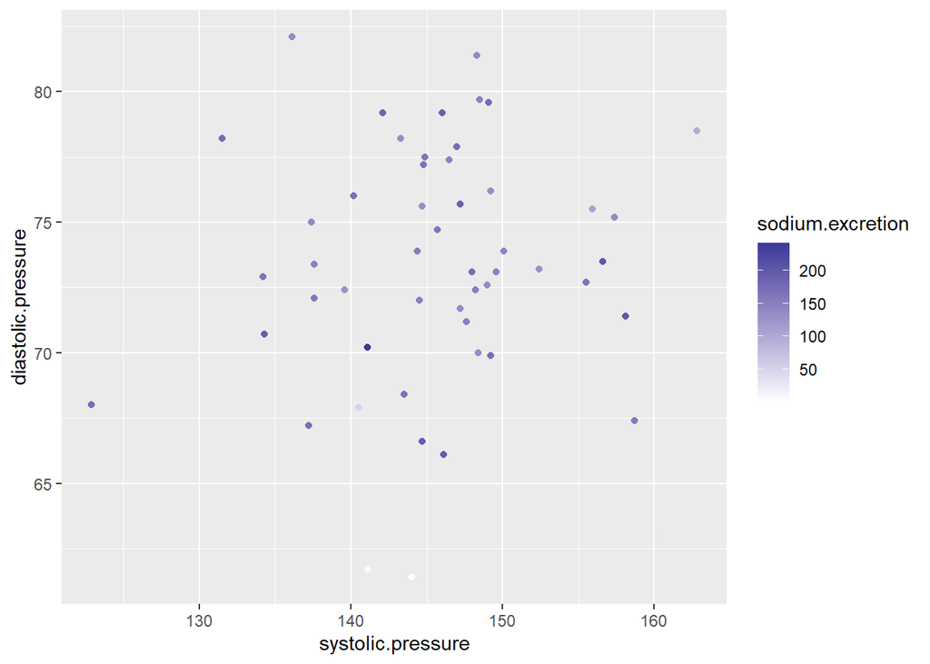

## and a table

A fundamental part of any report is the table of baseline characteristics, the Table 1.

```r
library(gtsummary)
library(gt)
# Summary statistics, by numeric variables and for all categorical variables
irs %>%
  select(-ID) %>%
  mutate(continent = countrycode::countrycode(sourcevar = irs$country,
                                              origin = "country.name",
                                              destination = "continent")) %>%
  select(-country) %>%
  tbl_summary(by = gender,
              lab = list(systolic.pressure ~ "Systolic pressure",
                         diastolic.pressure ~ "Diastolic pressure",
                         sodium.excretion ~ "Sodium excretion",
                         continent ~ "Continent"),
              statistic = list(systolic.pressure ~ "{mean} ({sd})",
                               diastolic.pressure ~ "{mean} ({sd})",
                               sodium.excretion ~ "{median} ({IQR})",
                               all_categorical() ~ "{n} / {N} ({p}%)")) %>%
# Add a label indicating the statistic
  add_stat_label() %>%
  add_p() %>%
  bold_p() %>%
  bold_labels() %>%
# Make a gt table
  as_gt() %>%
  # Add title and subtitle
  gt::tab_header(title = "Patient characteristics", subtitle = "Table 1") %>%
  # Change the background colour
  tab_options(table.background.color = "floralwhite",
              heading.background.color =  "darkslategray",
              table.font.names = "calibri") #%>%
```

Patient characteristics

Table 1

| **Characteristic** | **F**, N = 26 | **M**, N = 26 | **p-value**<sup>1</sup> |
| --- | --- | --- | --- |
| Systolic pressure, Mean (SD) | 143 (8) | 148 (7) | 0.038 |
| Diastolic pressure, Mean (SD) | 72.3 (5.3) | 74.0 (4.1) | 0.3 |
| Sodium excretion, Median (IQR) | 157 (40) | 152 (37) | 0.5 |
| Continent, n / N (%) |  |  | 0.031 |
| Africa | 1 / 26 (3.8%) | 1 / 26 (3.8%) |  |
| Americas | 8 / 26 (31%) | 6 / 26 (23%) |  |
| Asia | 1 / 26 (3.8%) | 9 / 26 (35%) |  |
| Europe | 15 / 26 (58%) | 10 / 26 (38%) |  |
| Oceania | 1 / 26 (3.8%) | 0 / 26 (0%) |  |

<sup>*1*</sup> Wilcoxon rank sum test; Wilcoxon rank sum exact test; Fisher's exact test

```r
#  as_rtf() -> tone
# write_file(tone, path = "C:/Users/fa/Documents/tone.rtf")
#-------
# The last part of the code let us save the table
# in Rich Text Format, which can be open with a word processor.
```

## Original data

```r
# An example of rectangular data exported as table with knitr::kable()
irs %>%
  mutate(continent = countrycode::countrycode(sourcevar = irs$country,
                                              origin = "country.name",
                                              destination = "continent")) %>%
  mutate(map = diastolic.pressure + 1/3*(systolic.pressure - diastolic.pressure)) %>%
  select(-ID) %>%
  knitr::kable()
```

| systolic.pressure | diastolic.pressure | sodium.excretion | country | gender | continent | map |
| --- | --- | --- | --- | --- | --- | --- |
| 144.5 | 72.0 | 149.3 | Argentina | M | Americas | 96.16667 |
| 143.3 | 78.2 | 133.0 | Belgium | M | Europe | 99.90000 |
| 150.1 | 73.9 | 142.6 | Belgium | M | Europe | 99.30000 |
| 141.1 | 61.7 | 5.8 | Brazil | F | Americas | 88.16667 |
| 144.0 | 61.4 | 0.2 | Brazil | F | Americas | 88.93333 |
| 137.6 | 73.4 | 148.9 | Canada | F | Americas | 94.80000 |
| 142.1 | 79.2 | 184.3 | Canada | M | Americas | 100.16667 |
| 144.7 | 66.6 | 194.1 | Colombia | F | Americas | 92.63333 |
| 136.1 | 82.1 | 135.6 | Denmark | F | Europe | 100.10000 |
| 137.4 | 75.0 | 138.7 | Germany | F | Europe | 95.80000 |
| 144.9 | 77.5 | 164.1 | Finland | F | Europe | 99.96667 |
| 146.5 | 77.4 | 144.4 | Finland | M | Europe | 100.43333 |
| 146.0 | 79.2 | 189.7 | Hungary | F | Europe | 101.46667 |
| 147.2 | 71.7 | 135.1 | Iceland | M | Europe | 96.86667 |
| 134.3 | 70.7 | 194.4 | India | M | Asia | 91.90000 |
| 144.4 | 73.9 | 153.2 | India | M | Asia | 97.40000 |
| 149.1 | 79.6 | 175.9 | Italy | F | Europe | 102.76667 |
| 149.2 | 69.9 | 169.9 | Italy | F | Europe | 96.33333 |
| 140.2 | 76.0 | 170.0 | Italy | F | Europe | 97.40000 |
| 134.2 | 72.9 | 162.6 | Italy | F | Europe | 93.33333 |
| 143.5 | 68.4 | 167.1 | Japan | M | Asia | 93.43333 |
| 137.2 | 67.2 | 171.2 | Japan | M | Asia | 90.53333 |
| 156.6 | 73.5 | 201.2 | Japan | M | Asia | 101.20000 |
| 140.5 | 67.9 | 51.3 | Kenya | F | Africa | 92.10000 |
| 144.8 | 77.2 | 165.6 | Malta | M | Europe | 99.73333 |
| 149.0 | 72.6 | 134.6 | Mexico | M | Americas | 98.06667 |
| 148.5 | 79.7 | 146.4 | Netherlands | M | Europe | 102.63333 |
| 160.4 | 62.9 | 26.8 | Papua New Guinea | F | Oceania | 95.40000 |
| 146.1 | 66.1 | 196.4 | China | M | Asia | 92.76667 |
| 158.7 | 67.4 | 158.1 | China | M | Asia | 97.83333 |
| 141.1 | 70.2 | 242.1 | China | F | Asia | 93.83333 |
| 147.2 | 75.7 | 191.8 | Poland | M | Europe | 99.53333 |
| 147.0 | 77.9 | 174.6 | Poland | M | Europe | 100.93333 |
| 131.5 | 78.2 | 175.4 | Portugal | F | Europe | 95.96667 |
| 158.1 | 71.4 | 201.4 | South Korea | M | Asia | 100.30000 |
| 137.6 | 72.1 | 161.8 | Russia | F | Europe | 93.93333 |
| 155.5 | 72.7 | 165.4 | Spain | M | Europe | 100.30000 |
| 122.9 | 68.0 | 175.2 | Spain | F | Europe | 86.30000 |
| 157.4 | 75.2 | 136.2 | Taiwan | M | Asia | 102.60000 |
| 155.9 | 75.5 | 108.3 | Trinidad | F | Americas | 102.30000 |
| 149.6 | 73.1 | 149.9 | UK | F | Europe | 98.60000 |
| 147.6 | 71.2 | 150.0 | UK | M | Europe | 96.66667 |
| 148.2 | 72.4 | 151.8 | UK | F | Europe | 97.66667 |
| 148.4 | 70.0 | 133.8 | USA | F | Americas | 96.13333 |
| 162.8 | 78.5 | 95.9 | USA | M | Americas | 106.60000 |
| 139.6 | 72.4 | 125.9 | USA | F | Americas | 94.80000 |
| 152.4 | 73.2 | 130.3 | USA | F | Americas | 99.60000 |
| 148.3 | 81.4 | 136.6 | USA | M | Americas | 103.70000 |
| 149.2 | 76.2 | 133.4 | USA | M | Americas | 100.53333 |
| 145.7 | 74.7 | 162.0 | Germany | F | Europe | 98.36667 |
| 148.0 | 73.1 | 172.0 | Germany | F | Europe | 98.06667 |
| 144.7 | 75.6 | 129.7 | Zimbabwe | M | Africa | 98.63333 |

# References

Riley, Richard D., Kym I. E. Snell, Joie Ensor, Danielle L. Burke, Frank E. Harrell Jr, Karel G. M. Moons, and Gary S. Collins. 2019. “Minimum Sample Size for Developing a Multivariable Prediction Model: Part I – Continuous Outcomes.” *Statistics in Medicine* 38 (7): 1262–75. https://doi.org/10.1002/sim.7993.